© Bản quyền thuộc về Quantopian Inc.  
© Bản quyền sửa đổi thuộc về AI Cafe¹  
Giấy phép [Creative Commons Attribution 4.0](https://creativecommons.org/licenses/by/4.0/legalcode).  
[Khuyến cáo](https://aicafe.one/khuyen-cao/)

# Đo lường mối quan hệ đơn điệu

By Evgenia "Jenny" Nitishinskaya and Delaney Granizo-Mackenzie with example algorithms by David Edwards

Edited by AI Cafe¹

Hệ số tương quan hạng Spearman cho phép chúng ta xác định liệu hai chuỗi dữ liệu có di chuyển cùng nhau hay không; tức là, khi một chuỗi tăng (giảm) thì chuỗi kia cũng tăng (giảm). Điều này tổng quát hơn một mối quan hệ tuyến tính; ví dụ, $y = e^x$ là một hàm đơn điệu, nhưng không phải là một hàm tuyến tính. Do đó, khi tính toán, chúng ta so sánh không phải dữ liệu thô mà là thứ hạng của dữ liệu.

Điều này rất hữu ích khi các tập dữ liệu của bạn có thể ở các đơn vị khác nhau, và do đó không có mối quan hệ tuyến tính (ví dụ, giá của một mảnh đất hình vuông và chiều dài cạnh của nó, vì giá có khả năng tuyến tính hơn với diện tích). Nó cũng phù hợp cho các tập dữ liệu không thỏa mãn các giả định mà các bài kiểm tra khác yêu cầu, chẳng hạn như các quan sát phải phân phối chuẩn như cần thiết cho một bài kiểm tra t-test.

```python
import numpy as np
import pandas as pd
import scipy.stats as stats
import matplotlib.pyplot as plt
import math
```

```python
# Example of ranking data
l = [10, 9, 5, 7, 5]
print('Raw data:', l)
print('Ranking:', list(stats.rankdata(l, method='average')))
```

```
Raw data: [10, 9, 5, 7, 5]
Ranking: [np.float64(5.0), np.float64(4.0), np.float64(1.5), np.float64(3.0), np.float64(1.5)]
```

## Hệ số tương quan hạng Spearman

### Trực giác

Trực giác ở đây là thay vì nhìn vào mối quan hệ giữa hai biến, chúng ta sẽ xem xét mối quan hệ giữa các hạng. Điều này giúp tránh ảnh hưởng của các giá trị ngoại lai và quy mô của dữ liệu.

### Định nghĩa

Tham số `method='average'` chỉ ra rằng khi có sự đồng hạng, chúng ta sẽ tính trung bình các hạng mà các số đó sẽ chiếm. Ví dụ, hai số $5$ ở trên, sẽ chiếm các hạng 1 và 2, mỗi số sẽ được gán một hạng là $1.5$.

Để tính hệ số tương quan hạng Spearman cho hai tập dữ liệu $X$ và $Y$, mỗi tập có kích thước $n$, chúng ta sử dụng công thức $$r_S = 1 - \frac{6 \sum_{i=1}^n d_i^2}{n(n^2 - 1)}$$

trong đó $d_i$ là sự khác biệt giữa các hạng của cặp quan sát thứ $i$, $X_i - Y_i$.

Kết quả sẽ luôn nằm trong khoảng từ $-1$ đến $1$. Giá trị dương cho thấy mối quan hệ dương giữa các biến, trong khi giá trị âm cho thấy mối quan hệ nghịch. Giá trị 0 ngụ ý không có mối quan hệ đơn điệu nào. Điều này không có nghĩa là không có mối quan hệ; ví dụ, nếu $Y$ bằng $X$ với độ trễ 2, chúng có mối liên hệ một cách đơn giản và chính xác, nhưng $r_S$ của chúng có thể gần bằng không:

## Thí nghiệm

```python
## Let's see an example of this
n = 100

def compare_correlation_and_spearman_rank(n, noise):
    X = np.random.poisson(size=n)
    Y = np.exp(X) + noise * np.random.normal(size=n)

    Xrank = stats.rankdata(X, method='average')
    # n-2 is the second to last element
    Yrank = stats.rankdata(Y, method='average')

    diffs = Xrank - Yrank # order doesn't matter since we'll be squaring these values
    r_s = 1 - 6*sum(diffs*diffs)/(n*(n**2 - 1))
    c_c = np.corrcoef(X, Y)[0,1]

    return r_s, c_c

experiments = 1000
spearman_dist = np.ndarray(experiments)
correlation_dist = np.ndarray(experiments)
for i in range(experiments):
    r_s, c_c = compare_correlation_and_spearman_rank(n, 1.0)
    spearman_dist[i] = r_s
    correlation_dist[i] = c_c

print('Spearman Rank Coefficient: ' + str(np.mean(spearman_dist)))
# Compare to the regular correlation coefficient
print('Correlation coefficient: ' + str(np.mean(correlation_dist)))
```

```
Spearman Rank Coefficient: 0.8763116231623163
Correlation coefficient: 0.77578081675317
```

Hãy xem xét phân phối của các hệ số tương quan đã đo và so sánh hệ số Spearman với thang đo thông thường.

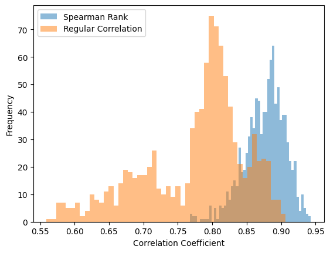

```python
plt.hist(spearman_dist, bins=50, alpha=0.5)
plt.hist(correlation_dist, bins=50, alpha=0.5)
plt.legend(['Spearman Rank', 'Regular Correlation'])
plt.xlabel('Correlation Coefficient')
plt.ylabel('Frequency');
```

Bây giờ hãy xem xét cách mà hệ số xếp hạng Spearman và hệ số thông thường xử lý khi chúng ta thêm nhiều nhiễu vào tình huống.

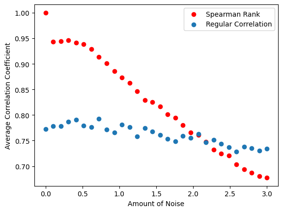

```python
n = 100
noises = np.linspace(0, 3, 30)
experiments = 100
spearman = np.ndarray(len(noises))
correlation = np.ndarray(len(noises))

for i in range(len(noises)):
    # Run many experiments for each noise setting
    rank_coef = 0.0
    corr_coef = 0.0
    noise = noises[i]
    for j in range(experiments):
        r_s, c_c = compare_correlation_and_spearman_rank(n, noise)
        rank_coef += r_s
        corr_coef += c_c
    spearman[i] = rank_coef/experiments
    correlation[i] = corr_coef/experiments

plt.scatter(noises, spearman, color='r')
plt.scatter(noises, correlation)
plt.legend(['Spearman Rank', 'Regular Correlation'])
plt.xlabel('Amount of Noise')
plt.ylabel('Average Correlation Coefficient')
```

Chúng ta có thể thấy rằng hệ số tương quan xếp hạng Spearman xử lý mối quan hệ phi tuyến tốt hơn ở hầu hết các mức độ nhiễu. Thú vị thay, ở các mức độ rất cao, nó dường như hoạt động kém hơn so với tương quan thông thường.

## Độ trễ trong tương quan

Hoặc có thể bạn gặp trường hợp một quá trình ảnh hưởng đến một quá trình khác, nhưng sau một khoảng thời gian trễ. Bây giờ hãy xem điều gì xảy ra nếu chúng ta thêm độ trễ.

```python
n = 100

X = np.random.rand(n)
Xrank = stats.rankdata(X, method='average')
# n-2 is the second to last element
Yrank = stats.rankdata([1,1] + list(X[:(n-2)]), method='average')

diffs = Xrank - Yrank # order doesn't matter since we'll be squaring these values
r_s = 1 - 6*sum(diffs*diffs)/(n*(n**2 - 1))
print(r_s)
```

```
-0.059570957095709476
```

Chắc chắn rồi, mối quan hệ không được phát hiện. Điều quan trọng khi sử dụng cả tương quan thông thường và tương quan Spearman là kiểm tra các mối quan hệ trễ bằng cách dịch chuyển dữ liệu của bạn và kiểm tra các giá trị dịch chuyển khác nhau.

## Hàm có sẵn trong Python

Chúng ta cũng có thể sử dụng hàm `spearmanr` trong thư viện `scipy.stats`:

```python
# Generate two random data sets
np.random.seed(161)
X = np.random.rand(10)
Y = np.random.rand(10)

r_s = stats.spearmanr(X, Y)
print('Spearman Rank Coefficient:', r_s[0])
print('p-value:', r_s[1])
```

```
Spearman Rank Coefficient: 0.23636363636363633
p-value: 0.5108853175152002
```

Chúng ta đã có được $r_S$, nhưng làm thế nào để chúng ta diễn giải nó? Nó dương, vì vậy chúng ta biết rằng các biến không có mối tương quan nghịch. Nó không quá lớn, vì vậy chúng ta biết rằng chúng không có mối tương quan dương hoàn hảo, nhưng thật khó để nói từ cái nhìn qua rằng mức độ tương quan này có ý nghĩa như thế nào. May mắn thay, `spearmanr` cũng tính toán giá trị p cho hệ số này và kích thước mẫu cho chúng ta. Chúng ta có thể thấy rằng giá trị p ở đây cao hơn 0.05; do đó, chúng ta không thể khẳng định rằng $X$ và $Y$ có mối tương quan.

## Trường Hợp Thực Tế: Đánh Giá Mô Hình Xếp Hạng

Lưu ý: Bài giảng Phân Tích Yếu Tố đề cập đến chủ đề này một cách chi tiết hơn.

Giả sử chúng ta có một cách nào đó để xếp hạng các chứng khoán và chúng ta muốn kiểm tra xem mô hình xếp hạng của chúng ta hoạt động tốt như thế nào trong thực tế. Trong trường hợp này, mô hình của chúng ta chỉ lấy lợi nhuận trung bình hàng ngày trong tháng vừa qua và xếp hạng các cổ phiếu dựa trên chỉ số đó.

Chúng ta giả định rằng điều này sẽ dự đoán được lợi nhuận trung bình trong tháng tiếp theo. Để kiểm tra điều này, chúng ta tính điểm cho các cổ phiếu dựa trên khoảng thời gian xem xét, sau đó lấy hệ số tương quan xếp hạng Spearman của điểm số và lợi nhuận trung bình trong tháng tiếp theo.

```python
# Cài thư viện lấy dữ liệu miễn phí
!curl -fsSLO https://raw.githubusercontent.com/algo-stocks/data/master/data.py
```

```
Our Scores

FPT    0.003400
BID   -0.001039
VCB   -0.001522
CTG    0.002649
SSI    0.003181
MBB    0.001898
HPG   -0.000360
dtype: float64


The Walk Forward Returns

FPT    0.000646
BID    0.002968
VCB    0.000497
CTG   -0.000106
SSI   -0.001594
MBB    0.001444
HPG   -0.000988
dtype: float64


Correlation Coefficient:-0.28571428571428575
p-value:0.5345092286010406
```

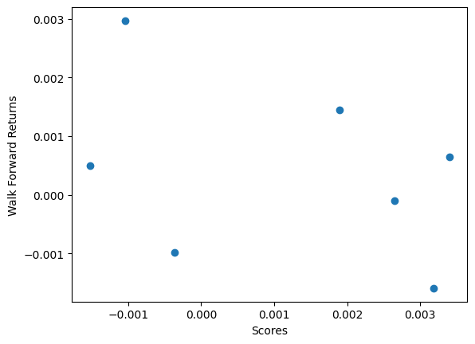

```python
from data import get_prices

# Get the returns over the lookback window
start = '2024-12-01'
end = '2025-01-01'

prices = get_prices('FPT', 'BID', 'VCB', 'CTG', 'SSI', 'MBB', 'HPG', start_date=start, end_date=end)
historical_returns = prices.pct_change()[1:]

# Compute our stock score
scores = np.mean(historical_returns, axis=0)
print('Our Scores\n')
print(scores)
print('\n')

start = '2025-01-01'
end = '2025-02-01'
prices = get_prices('FPT', 'BID', 'VCB', 'CTG', 'SSI', 'MBB', 'HPG', start_date=start, end_date=end)
walk_forward_returns = prices.pct_change()[1:]
walk_forward_returns = np.mean(walk_forward_returns, axis=0)
print('The Walk Forward Returns\n')
print(walk_forward_returns)
print('\n')

plt.scatter(scores, walk_forward_returns)
plt.xlabel('Scores')
plt.ylabel('Walk Forward Returns')

r_s = stats.spearmanr(scores, walk_forward_returns)
print('Correlation Coefficient:' + str(r_s[0]))
print('p-value:' + str(r_s[1]))
```

Giá trị p-value cho thấy giả thuyết của chúng ta là sai và chúng ta chấp nhận giả thuyết null rằng xếp hạng của chúng ta không tốt hơn ngẫu nhiên. Đây là một cách kiểm tra rất tốt cho bất kỳ hệ thống xếp hạng nào mà người ta xây dựng để tạo ra một danh mục đầu tư cổ phiếu Long-Short.

## Tham khảo

- DeFusco, Richard A. "Tests Concerning Correlation: The Spearman Rank Correlation Coefficient." *Quantitative Investment Analysis*. Hoboken, NJ: Wiley, 2007

*Lưu ý: Tài liệu này mang tính chất chia sẻ kiến thức khoa học dữ liệu. Các mã chứng khoán xuất hiện trong tài liệu chỉ mang tính chất minh hoạ, không khuyến nghị đầu tư. Chúng tôi không chịu trách nhiệm trước mọi rủi ro nào do sử dụng tài liệu này.*